# Assignment_03

Author

Nicole Tang

## Due Date

This assignment is due by 11:59pm Pacific Time, November 8th, 2024.

## Text Mining

A new dataset has been added to the data science data repository https://github.com/USCbiostats/data-science-data/tree/master/03_pubmed. The dataset contains 3,241 abstracts from articles collected via 5 PubMed searches. The search terms are listed in the second column, `term` and these will serve as the “documents.” Your job is to analyse these abstracts to find interesting insights.

1. Tokenize the abstracts and count the number of each token. Do you see anything interesting? Does removing stop words change what tokens appear as the most frequent? What are the 5 most common tokens for each search term after removing stopwords?

```r
#read in data
data <- read_csv("pubmed.csv")
head(data)
```

```
# A tibble: 6 × 2
  abstract                                                                 term
  <chr>                                                                    <chr>
1 "Background and aims: Many patients with coronavirus disease 2019 (COVI… covid
2 "Introduction: Contradictory data have been reported on the incidence o… covid
3 "This article aims at collecting all information needed for dentists re… covid
4 "OBJECTIVE. The objective of our study was to determine the misdiagnosi… covid
5 "Background: Much of the focus regarding the global pandemic of coronav… covid
6 "The World Health Organization (WHO) has issued a warning that, althoug… covid
```

```r
#tokenize
tokenize <- data %>%
  unnest_tokens(token, abstract)

tokenize %>%
  count(token, sort = TRUE)
```

```
# A tibble: 20,567 × 2
   token     n
   <chr> <int>
 1 the   28126
 2 of    24760
 3 and   19993
 4 in    14653
 5 to    10920
 6 a      8245
 7 with   8038
 8 covid  7275
 9 19     7080
10 is     5649
# ℹ 20,557 more rows
```

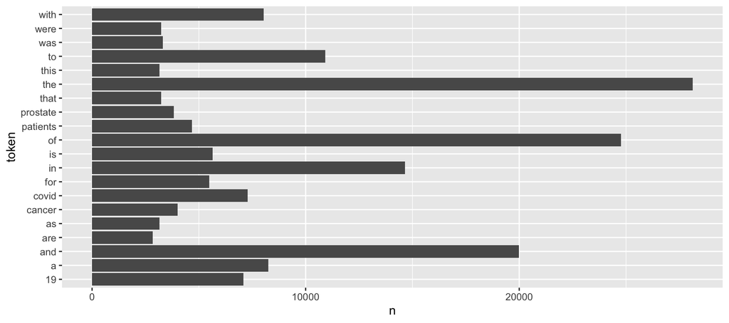

```r
tokenize %>%
  count(token)  %>%
  top_n(20, n)  %>%
  ggplot(aes(n, token)) +
  geom_col()
```

**The top words before removing stop words appear to be stop words**

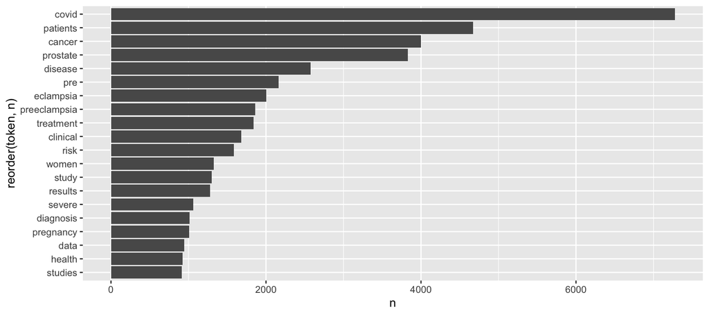

```r
#remove stop words
important_words <- tokenize %>%
  anti_join(stop_words, by = c("token" = "word")) |>
  filter(!str_detect(token, "^[0-9]+$")) |>
  count(token, sort = TRUE)

plot <- important_words %>%
  top_n(20, n)  %>%
  arrange(desc(n)) %>%
  ggplot(aes(x = n, y = reorder(token, n)))+
  geom_col()

print(plot)
```

**After removing stop words, the top words are covid, patients, cancer, postate, and disease**

```r
#group important words by term
top5 <- data %>%
  unnest_tokens(token, abstract) %>%
  anti_join(stop_words, by = c("token" = "word")) %>%
  filter(!str_detect(token, "^[0-9]+$")) %>%
  group_by(term) %>%
  count(token, sort = TRUE) %>%
  slice_max(n, n = 5) %>%
  ungroup()

print (top5)
```

```
# A tibble: 26 × 3
   term            token           n
   <chr>           <chr>       <int>
 1 covid           covid        7275
 2 covid           patients     2293
 3 covid           disease       943
 4 covid           pandemic      800
 5 covid           coronavirus   647
 6 covid           health        647
 7 cystic fibrosis fibrosis      867
 8 cystic fibrosis cystic        862
 9 cystic fibrosis cf            625
10 cystic fibrosis patients      586
# ℹ 16 more rows
```

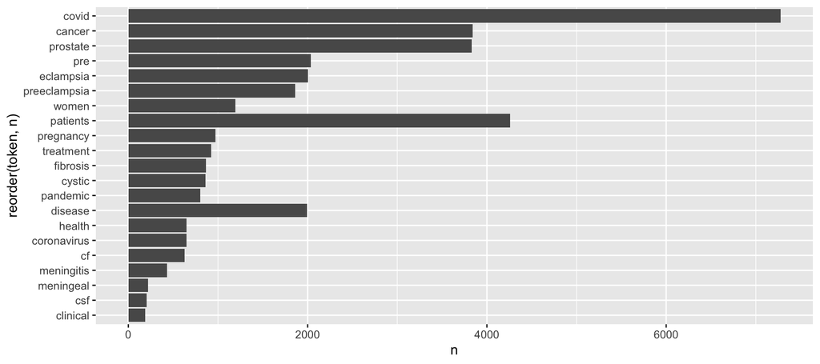

```r
plot2 <- top5 %>%
  arrange(desc(n)) %>%
  ggplot(aes(x = n, y = reorder(token, n)))+
  geom_col()

print(plot2)
```

**The top words grouped by term** **covid- covid, patients, disease, pandemic, coronavirus** **cystic fibrosis- fibrosis, cystic, cf, patients, disease** **meningitis- patients, meningitis, meningeal, csf, clinical** **preclampsia- pre, eclpampsia, preexlampsia, women, pregnancy** **prostate cencer- cancer, prostate, patients, treatment, disease**

**The top words by type appear to be related to the name**

2. Tokenize the abstracts into bigrams. Find the 10 most common bigrams and visualize them with ggplot2.

```r
#make bigrams
bi <- data %>%
  unnest_ngrams(ngram, abstract, n = 2)

bi %>%
  count(ngram, sort = TRUE)
```

```
# A tibble: 199,506 × 2
   ngram               n
   <chr>           <int>
 1 covid 19         6969
 2 of the           3883
 3 in the           3418
 4 prostate cancer  3222
 5 pre eclampsia    1854
 6 patients with    1587
 7 of covid         1519
 8 and the          1154
 9 to the           1061
10 of prostate       870
# ℹ 199,496 more rows
```

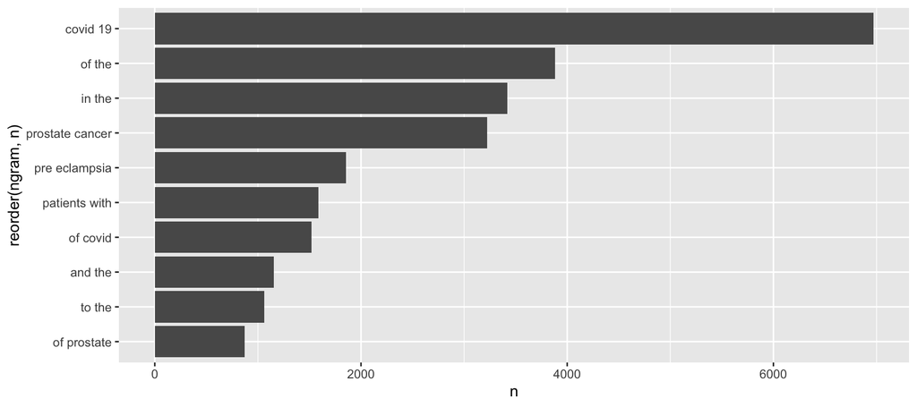

```r
plotbi <- bi %>%
  count(ngram)  %>%
  top_n(10, n)  %>%
  arrange(desc(n)) %>%
  ggplot(aes(x = n, y = reorder(ngram, n))) +
  geom_col()

print(plotbi)
```

**The most popular bigrams are covid 19, of the, in the, and prostate cancer**

3. Calculate the TF-IDF value for each word-search term combination (here you want the search term to be the “document”). What are the 5 tokens from each search term with the highest TF-IDF value? How are the results different from the answers you got in question 1?

```r
#calculate tf-idf
idf <- data |>
  unnest_tokens(abstract, abstract) |>
  count(abstract, term) |>
  bind_tf_idf(abstract, term, n) |>
  arrange(desc(tf_idf))

head(idf)
```

```
# A tibble: 6 × 6
  abstract     term                n      tf   idf tf_idf
  <chr>        <chr>           <int>   <dbl> <dbl>  <dbl>
1 covid        covid            7275 0.0371  1.61  0.0597
2 prostate     prostate cancer  3832 0.0312  1.61  0.0502
3 eclampsia    preeclampsia     2005 0.0143  1.61  0.0230
4 preeclampsia preeclampsia     1863 0.0133  1.61  0.0214
5 meningitis   meningitis        429 0.00919 1.61  0.0148
6 cf           cystic fibrosis   625 0.0127  0.916 0.0117
```

```r
top_tf_idf <- idf %>%
  group_by(term) %>%
  slice_max(tf_idf, n = 5) %>%
  ungroup()

print(top_tf_idf)
```

```
# A tibble: 25 × 6
   abstract    term                n      tf   idf  tf_idf
   <chr>       <chr>           <int>   <dbl> <dbl>   <dbl>
 1 covid       covid            7275 0.0371  1.61  0.0597
 2 pandemic    covid             800 0.00408 1.61  0.00657
 3 coronavirus covid             647 0.00330 1.61  0.00531
 4 sars        covid             372 0.00190 1.61  0.00305
 5 cov         covid             334 0.00170 1.61  0.00274
 6 cf          cystic fibrosis   625 0.0127  0.916 0.0117
 7 fibrosis    cystic fibrosis   867 0.0176  0.511 0.00901
 8 cystic      cystic fibrosis   862 0.0175  0.511 0.00896
 9 cftr        cystic fibrosis    86 0.00175 1.61  0.00282
10 sweat       cystic fibrosis    83 0.00169 1.61  0.00272
# ℹ 15 more rows
```

**The top words grouped by term** **covid- covid, pandemic, sars, cov, coronavirus** **cystic fibrosis- fibrosis, cystic, cf, ctfr, sweat** **meningitis- meningitis, meningeal, pachmeningitis, csf, meninges** **preclampsia- maternal, eclpampsia, preeclampsia, gestational, pregnancy** **prostate cencer- androgen, prostate, psa, prostatectomy, castration** **These words differ from the tokenized words. They are more scientific and medical**

## Sentiment Analysis

1. Perform a sentiment analysis using the NRC lexicon. What is the most common sentiment for each search term? What if you remove `"positive"` and `"negative"` from the list?

```r
get_sentiments('nrc')
```

```
# A tibble: 13,872 × 2
   word        sentiment
   <chr>       <chr>
 1 abacus      trust
 2 abandon     fear
 3 abandon     negative
 4 abandon     sadness
 5 abandoned   anger
 6 abandoned   fear
 7 abandoned   negative
 8 abandoned   sadness
 9 abandonment anger
10 abandonment fear
# ℹ 13,862 more rows
```

```r
data |>
  unnest_tokens(word, abstract) |>
  inner_join(get_sentiments("nrc")) |>
  group_by(term) |>
  summarise(sentiment = names(which.max(table(sentiment))))
```

```
# A tibble: 5 × 2
  term            sentiment
  <chr>           <chr>
1 covid           positive
2 cystic fibrosis positive
3 meningitis      negative
4 preeclampsia    positive
5 prostate cancer negative
```

**The top positive terms are covid, cystic fibrosis, and preeclampsia. The top negative terms are meningitis and prostate cancer**

```r
nrc_fun <- get_sentiments("nrc")
nrc_fun <- nrc_fun[!nrc_fun$sentiment %in% c("positive","negative"), ]

data |>
  unnest_tokens(word, abstract) |>
  inner_join(nrc_fun) |>
  group_by(term) |>
  summarise(sentiment = names(which.max(table(sentiment))))
```

```
# A tibble: 5 × 2
  term            sentiment
  <chr>           <chr>
1 covid           fear
2 cystic fibrosis disgust
3 meningitis      fear
4 preeclampsia    anticipation
5 prostate cancer fear
```

**The top words are covid (fear), cystic fibrosis(disgust), meningitis (fear), preeclampsia(anticipation), and prostate cancer (fear)**

2. Now perform a sentiment analysis using the AFINN lexicon to get an average positivity score for each abstract (hint: you may want to create a variable that indexes, or counts, the abstracts). Create a visualization that shows these scores grouped by search term. Are any search terms noticeably different from the others?

```r
get_sentiments('afinn')
```

```
# A tibble: 2,477 × 2
   word       value
   <chr>      <dbl>
 1 abandon       -2
 2 abandoned     -2
 3 abandons      -2
 4 abducted      -2
 5 abduction     -2
 6 abductions    -2
 7 abhor         -3
 8 abhorred      -3
 9 abhorrent     -3
10 abhors        -3
# ℹ 2,467 more rows
```

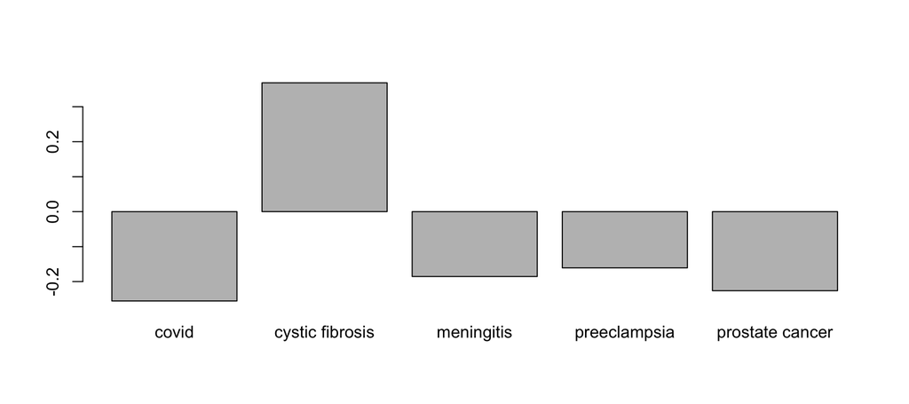

```r
avg_by_term <- data |>
  unnest_tokens(word, abstract) |>
  inner_join(get_sentiments("afinn")) |>
  group_by(term) |>
  summarise(sentiment = mean(value))
barplot(avg_by_term$sentiment, names.arg = avg_by_term$term)
```

**Cystic fibrosis is positive while covid, meningitis, preeclampsia, and prostate cancer are negative**